# Case Study 1

Joaquin

10/8/2021

Abstract

Two data sets were provided to explore the relationship between the varaiables contained therein. ABV and IBU served as continous quantitative variables and geographic location of breweries, brewery names, and styles of beer served as discrete categorical variables. The relationship between IBU and ABV, especially with respect to beer styles, was found to be significant (Pearson r: 0.67, p-val <.0001). This was further confirmed by a knn machine learning model. Based on these insights, additional machine learning models were created to predict styles of beer given geographic location and vice-versa. We suggest that these models and insights be applied for R&D and marketing purposes.

## **Setting up**

### *Loading necessary libraries*

## R Markdown

```r
library(tidyverse)
library(ggpubr)
library(class)
library(caret)
library(e1071)
library(rvest)
```

### *reading in the data*

```r
beers <- read_csv("https://raw.githubusercontent.com/BivinSadler/MSDS_6306_Doing-Data-Science/Master/Unit%208%20and%209%20Case%20Study%201/Beers.csv")
breweries <- read_csv("https://raw.githubusercontent.com/BivinSadler/MSDS_6306_Doing-Data-Science/Master/Unit%208%20and%209%20Case%20Study%201/Breweries.csv")
```

## Breweries per State

```r
##How many breweries are present in each state?
#This table outlines the quantity of breweries in each state and will be used as the basis of the following charts.
numbystate <- data.frame(breweries %>% count(State))
numbystate
```

```
##    State  n
## 1     AK  7
## 2     AL  3
## 3     AR  2
## 4     AZ 11
## 5     CA 39
## 6     CO 47
## 7     CT  8
## 8     DC  1
## 9     DE  2
## 10    FL 15
## 11    GA  7
## 12    HI  4
## 13    IA  5
## 14    ID  5
```

[output cut: 37 more lines]

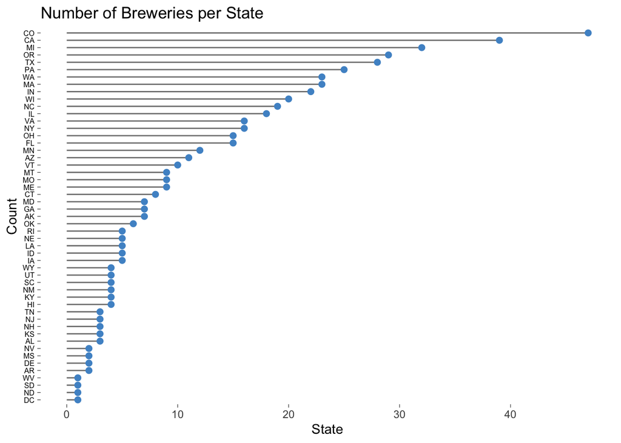

```r
numbystate$State <- as.factor(numbystate$State)

#bar graph depicting the number of breweries in each state
numbystate %>% ggplot(aes(x = reorder(State, n), y = n)) +
  geom_segment(aes(xend=State, yend=0), color = 'grey50') +
  geom_point(size=2, color="steelblue3") +
  coord_flip() +
  theme(legend.position = "none") +
  theme(axis.text.y = element_text(size = 6, color = "black")) +
  theme(panel.background = element_rect(fill = "white")) +
  theme(axis.ticks = element_line(size = .2)) +
  labs(x = "Count", y = "State") +
  ggtitle("Number of Breweries per State")
```

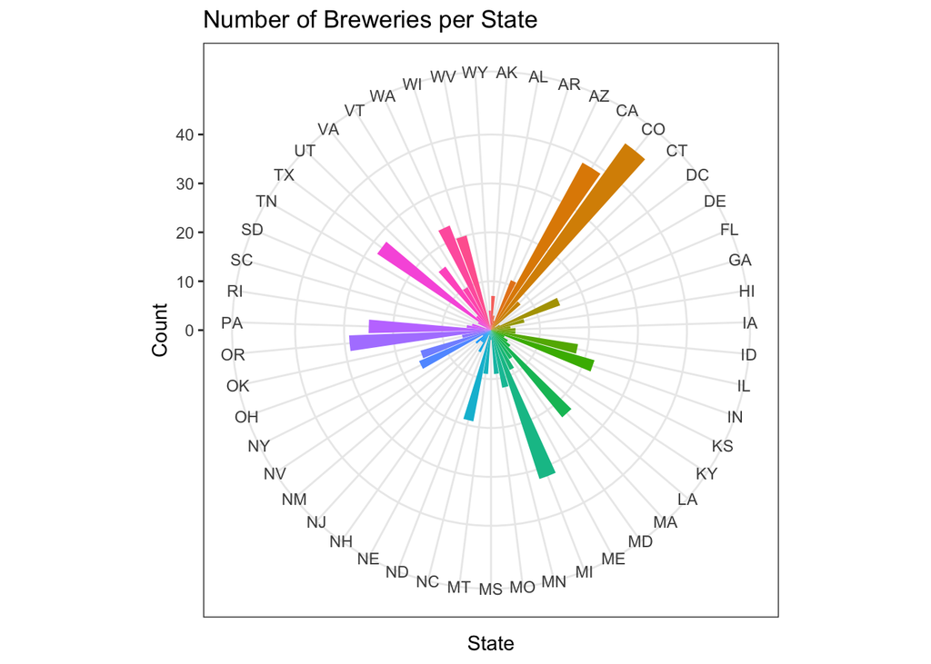

```r
#Different chart (polar coordinates) giving a better visualization of relative amount of breweries in each state.

numbystate %>% ggplot(aes(x = State, y = n, fill = State)) +
  geom_bar(stat = 'identity') +
  coord_polar() + theme_bw() +
  theme(legend.position = "none") +
  labs(x = "State", y = "Count") + ggtitle("Number of Breweries per State")
```

```r
## A more accurate representation of brewery density is depicted by determining Breweries per Capita. Data was accessed via the US Census Bureau API

statepop <- read_csv("https://raw.githubusercontent.com/j-dominguez9/Case-Study-1/main/Code/Tables/statepop.csv")
```

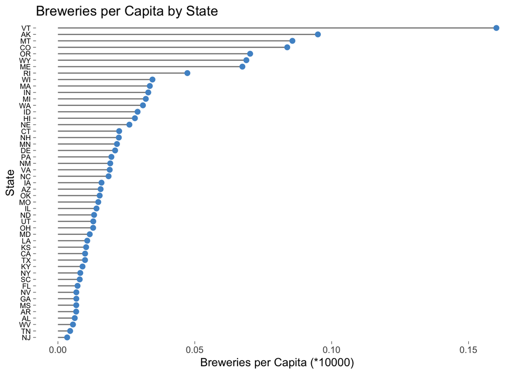

```r
#Join census data with previous table(numbystate)
breweriespercapita <- full_join(numbystate, statepop, by = "State") %>%
  mutate(bpc = (n/population)*10000) %>%
  mutate(State = as.factor(State))

#Plot
breweriespercapita %>% filter(!is.na(population)) %>% filter(!State == "SD") %>%
  ggplot(aes(x = reorder(State, bpc), y = bpc)) +
  geom_segment(aes(xend=State, yend=0), color = 'grey50') +
  geom_point(size=2, color="steelblue3") +
  coord_flip() +
  theme(legend.position = "none") +
  theme(axis.text.y = element_text(size = 7, color = "black")) +
  theme(panel.background = element_rect(fill = "white")) +
  theme(axis.ticks = element_line(size = .2)) +
  ggtitle("Breweries per Capita by State") +
  labs(x = "State", y = "Breweries per Capita (*10000)")
```

### Addressing Missing Values

```r
##Address the missing values in each column.
sum(is.na(breweries))
```

```
## [1] 0
```

```r
#As we can see, the breweries data set holds no missing values, thus no need to eliminate any missing values.

sum(is.na(beers))
```

```
## [1] 1072
```

```r
#The beers dataset has 1072, so we must eliminate noted values.

beers_clean <- beers %>% filter(!is.na(Name)) %>% filter(!is.na(Beer_ID)) %>%
  filter(!is.na(ABV)) %>% filter(!is.na(IBU)) %>%
  filter(!is.na(Brewery_id)) %>% filter(!is.na(Style)) %>%
  filter(!is.na(Ounces))

#Removed 1007 rows due to missing values.
```

### Median ABV and IBU

```r
##Compute the median alcohol content and international bitterness unit for each state. Plot a bar chart to compare.

#In order to join the two data sets successfully, we will need to find a primary key and a foreign key by which to join by. Let's examine the column names.

colnames(breweries)
```

```
## [1] "Brew_ID" "Name"    "City"    "State"
```

```r
colnames(beers_clean)
```

```
## [1] "Name"       "Beer_ID"    "ABV"        "IBU"        "Brewery_id"
## [6] "Style"      "Ounces"
```

```r
#As we can see, Brewery ID would be a good key to join them; however, we must make sure that they have a common spelling. Also, even though 'Name" makes sense for each respective dataset, we will need to change it in order to clarify what the column is indeed naming when joining.

breweries$Brewery = breweries$Name
breweries$Brewery_id = breweries$Brew_ID
head(breweries)
```

```
## # A tibble: 6 × 6
##   Brew_ID Name                      City          State Brewery       Brewery_id
##     <dbl> <chr>                     <chr>         <chr> <chr>              <dbl>
## 1       1 NorthGate Brewing         Minneapolis   MN    NorthGate Br…          1
## 2       2 Against the Grain Brewery Louisville    KY    Against the …          2
## 3       3 Jack's Abby Craft Lagers  Framingham    MA    Jack's Abby …          3
## 4       4 Mike Hess Brewing Company San Diego     CA    Mike Hess Br…          4
## 5       5 Fort Point Beer Company   San Francisco CA    Fort Point B…          5
## 6       6 COAST Brewing Company     Charleston    SC    COAST Brewin…          6
```

```r
#Let's create a new dataframe with the relevant columns from 'breweries' before joining.

breweries_clean <- breweries %>% select(Brewery, City, State, Brewery_id)
join <- inner_join(breweries_clean, beers_clean, by = "Brewery_id")
head(join)
```

```
## # A tibble: 6 × 10
##   Brewery   City   State Brewery_id Name   Beer_ID   ABV   IBU Style      Ounces
##   <chr>     <chr>  <chr>      <dbl> <chr>    <dbl> <dbl> <dbl> <chr>       <dbl>
## 1 NorthGat… Minne… MN             1 Get T…    2692 0.045    50 American …     16
## 2 NorthGat… Minne… MN             1 Maggi…    2691 0.049    26 Milk / Sw…     16
## 3 NorthGat… Minne… MN             1 Wall'…    2690 0.048    19 English B…     16
## 4 NorthGat… Minne… MN             1 Pumpi…    2689 0.06     38 Pumpkin A…     16
## 5 NorthGat… Minne… MN             1 Stron…    2688 0.06     25 American …     16
## 6 NorthGat… Minne… MN             1 Parap…    2687 0.056    47 Extra Spe…     16
```

```r
tail(join)
```

```
## # A tibble: 6 × 10
##   Brewery    City   State Brewery_id Name     Beer_ID   ABV   IBU Style   Ounces
##   <chr>      <chr>  <chr>      <dbl> <chr>      <dbl> <dbl> <dbl> <chr>    <dbl>
## 1 Pyramid B… Seatt… WA           545 Pyramid…     399 0.052    18 Hefewe…     12
## 2 Pyramid B… Seatt… WA           545 Haywire…      82 0.052    18 Hefewe…     16
## 3 Lancaster… Lanca… PA           546 Rumspri…     392 0.066    30 Maiboc…     12
## 4 Lancaster… Lanca… PA           546 Lancast…     195 0.048    28 Kölsch      12
## 5 Upstate B… Elmira NY           547 Common …     382 0.053    22 Americ…     16
## 6 Upstate B… Elmira NY           547 Upstate…     381 0.065    70 Americ…     12
```

```r
#From the joined data frame, let's select the relevant columns.

medABVIBU <- join %>% select(State, ABV, IBU)
head(medABVIBU)
```

```
## # A tibble: 6 × 3
##   State   ABV   IBU
##   <chr> <dbl> <dbl>
## 1 MN    0.045    50
## 2 MN    0.049    26
## 3 MN    0.048    19
## 4 MN    0.06     38
## 5 MN    0.06     25
## 6 MN    0.056    47
```

```r
#Having the relevant columns to work with, lets create a new one with the median ABV of each state and call it 'medABV'.
medABV <- medABVIBU %>% group_by(State) %>% mutate(medianABV = median(ABV)*100) %>% select(State, medianABV) %>% arrange(State) %>% distinct(State, medianABV)
head(medABV)
```

```
## # A tibble: 6 × 2
## # Groups:   State [6]
##   State medianABV
##   <chr>     <dbl>
## 1 AK          5.7
## 2 AL          6
## 3 AR          4
## 4 AZ          5.5
## 5 CA          5.8
## 6 CO          6.5
```

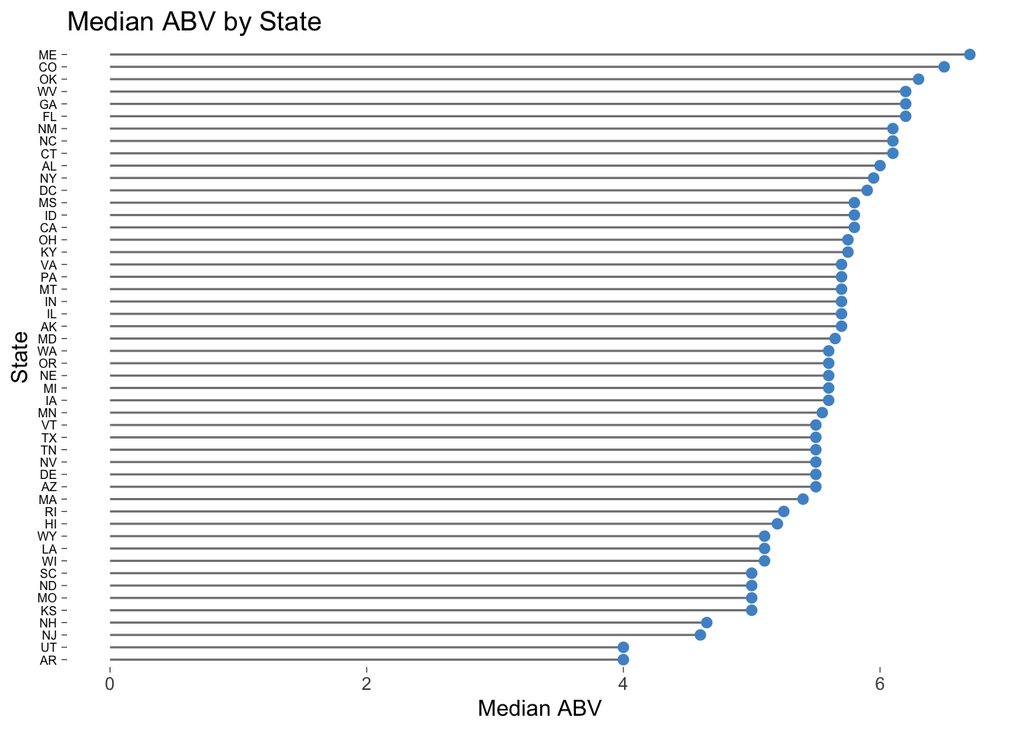

```r
##Data set is now ready to plot.

medABV %>% ggplot(aes(x = reorder(State, medianABV), y = medianABV)) +
geom_segment(aes(xend=State, yend=0), color = 'grey50') +
  geom_point(size=2, color="steelblue3") +
  coord_flip() +
  theme(legend.position = "none") +
  theme(axis.text.y = element_text(size = 6, color = "black")) +
  theme(panel.background = element_rect(fill = "white")) +
  theme(axis.ticks = element_line(size = .2)) +
  labs(x = "State", y = "Median ABV") +
  ggtitle("Median ABV by State")
```

```r
##We will follow a similar process to derive median IBU by State.

medIBU <- medABVIBU %>%
  group_by(State) %>%
  mutate(medianIBU = median(IBU)) %>%
  select(State, medianIBU) %>%
  arrange(State) %>%
  distinct(State, medianIBU)

head(medIBU)
```

```
## # A tibble: 6 × 2
## # Groups:   State [6]
##   State medianIBU
##   <chr>     <dbl>
## 1 AK           46
## 2 AL           43
## 3 AR           39
## 4 AZ           20
## 5 CA           42
## 6 CO           40
```

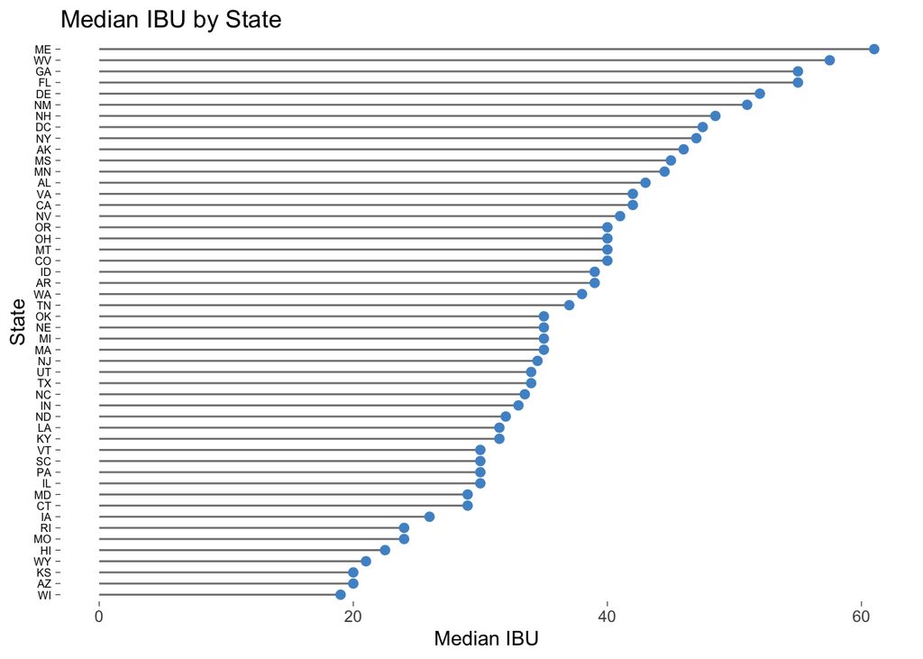

```r
#And plot in a similar manner.

medIBU %>% ggplot(aes(x = reorder(State, medianIBU), y = medianIBU)) +
 geom_segment(aes(xend=State, yend=0), color = 'grey50') +
  geom_point(size=2, color="steelblue3") +
  coord_flip() +
  theme(legend.position = "none") +
  theme(axis.text.y = element_text(size = 6, color = "black")) +
  theme(panel.background = element_rect(fill = "white")) +
  theme(axis.ticks = element_line(size = .2)) +
  labs(x = "State", y = "Median IBU") +
  ggtitle("Median IBU by State")
```

### Max ABV and IBU

```r
##Which state has the maximum alcoholic (ABV) beer? Which state has the most bitter (IBU) beer?

#We will create a new data frame with relevant columns to explore this question.
maxABVIBU <- join %>% select(Brewery, Name, State, ABV, IBU)

#We need to identify the highest ABV level
max(maxABVIBU$ABV)
```

```
## [1] 0.125
```

```r
maxABVIBU %>% filter(ABV == "0.125")
```

```
## # A tibble: 1 × 5
##   Brewery                   Name           State   ABV   IBU
##   <chr>                     <chr>          <chr> <dbl> <dbl>
## 1 Against the Grain Brewery London Balling KY    0.125    80
```

```r
## We can see that the beer with the highest ABV belongs to the state of Kentucky (KY) with an ABV of 12.5. The beer is "London Balling" by Against the Grain Brewery.

#We follow the same process for IBU.
max(maxABVIBU$IBU)
```

```
## [1] 138
```

```r
maxABVIBU %>% filter(IBU == "138")
```

```
## # A tibble: 1 × 5
##   Brewery                 Name                      State   ABV   IBU
##   <chr>                   <chr>                     <chr> <dbl> <dbl>
## 1 Astoria Brewing Company Bitter Bitch Imperial IPA OR    0.082   138
```

```r
#The beer with the highest IBU belongs to the state of Oregon (OR) with an IBU of 138. The beer is "Bitter Bitch Imperial IPA" by Astoria Brewing Company.
```

### Summary and Distribution of ABV

```r
summary(maxABVIBU$ABV)
```

```
##    Min. 1st Qu.  Median    Mean 3rd Qu.    Max.
## 0.02700 0.05000 0.05700 0.05992 0.06800 0.12500
```

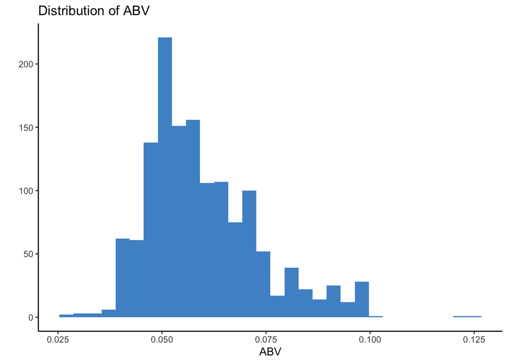

```r
#Histogram
maxABVIBU %>% ggplot(aes(x = ABV)) +
  geom_histogram(fill = "steelblue3") +
  theme_classic() +
  labs(x = "ABV", y = "") +
  ggtitle("Distribution of ABV")
```

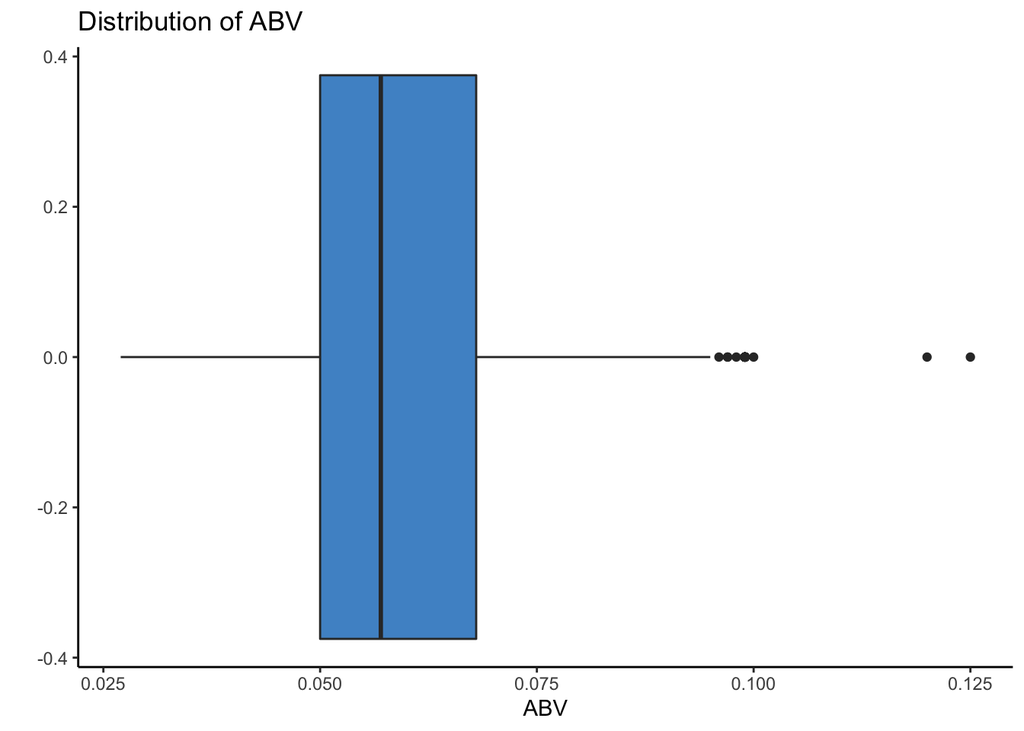

```r
#Boxplot
maxABVIBU %>% ggplot(aes(x = ABV)) +
  geom_boxplot(fill = "steelblue3") +
  theme_classic() +
  labs(x = "ABV", y = "") +
  ggtitle("Distribution of ABV")
```

```r
#Through visual inspection, we can see a right skew distribution in ABV. A log transformation may be appropriate for regression or t-test purposes.
```